# Macrochelys temminckii

## Alligator Snapping Turtle

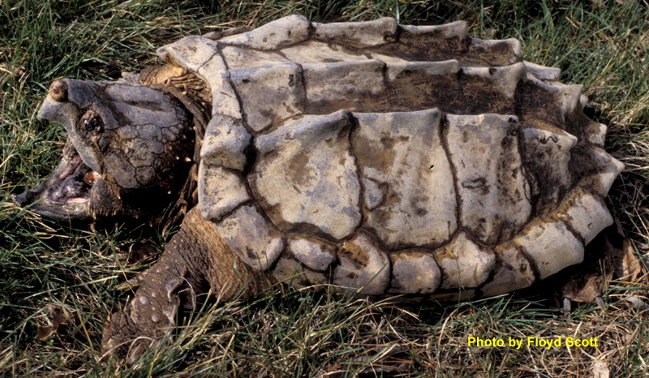

### **Current Species Distribution Within Tennessee**

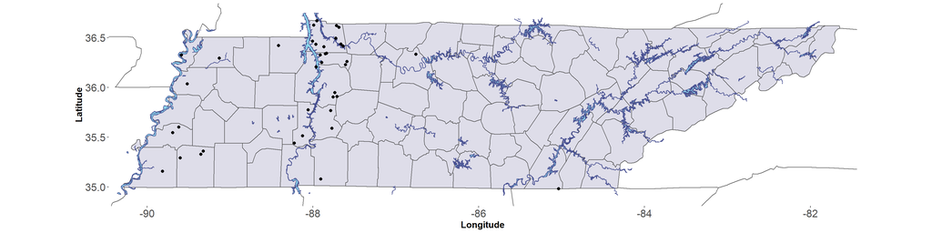

Taxonomy: No subspecies are recognized (Iverson et al. 2012).

Distribution: In Tennessee, the Alligator Snapping Turtle has been documented from the following major drainages and bodies of water therein: 1) Mississippi River drainage in the Wolf River, Hatchie River, Obion River, and Reelfoot Lake; 2) Tennessee River drainage in Wolfever Creek (tributary to Chickamauga Lake) and a number of western and eastern tributaries of Kentucky Lake; and 3) Cumberland River drainage in Lake Barkley, Stones River below Percy Priest Dam, and Radnor Lake’s spillway pool (Harpeth River drainage). The type locality of Macrochelys temminckii (Chelonura temminckii in the original description) was given as “a tributary stream of the Mississippi, which enters that river above Memphis, in West Tennessee” (Harlan 1835). Due to the imprecise nature of this locality statement, we did not attempt to plot the type locality, although it is probably the Wolf or Loosahatchie River.

### **Specimen Records Within Tennessee**

| County | Specimen Numbers |
| --- | --- |
| BENTON | APSU:Herp:03289 |
| DAVIDSON | APSU:Herp:19552 |
| DECATUR | APSU:Herp:19572, APSU:Herp:19965, APSU:Herp:19966 |
| DEKALB | APSU:Herp:19836, APSU:Herp:19901 |
| DYER | APSU:Herp:19884 |
| FAYETTE | APSU:Herp:03341, APSU:Herp:18130, APSU:Herp:19880 |
| HAMILTON | APSU:Herp:17486 |
| HENRY | APSU:Herp:01038 |
| HOUSTON | APSU:Herp:05443, APSU:Herp:05490, APSU:Herp:05526, APSU:Herp:06043, APSU:Herp:06048, APSU:Herp:06123 |
| HUMPHREYS | APSU:Herp:03843, APSU:Herp:06058, APSU:Herp:06124 |
| LAKE | APSU:Herp:19879 |
| OBION | APSU:Herp:19885 |
| PERRY | APSU:Herp:19737, APSU:Herp:19738 |
| SHELBY | APSU:Herp:19802 |
| STEWART | APSU:Herp:04738, APSU:Herp:04751, APSU:Herp:04762, APSU:Herp:05267, APSU:Herp:05366, APSU:Herp:05434, APSU:Herp:05435, APSU:Herp:05436, APSU:Herp:05437, APSU:Herp:05438 |
| TIPTON | APSU:Herp:19066, APSU:Herp:19554 |
| WAYNE | APSU:Herp:18868 |

Questionable or Erroneous Records: The Hamilton County record (APSU 17486) reported by Ekkens and Collins (2008) was taken 550 river kilometers upstream from the nearest record in the Tennessee River drainage. Although belonging to Haplotype A, which is commonly found in the Tennessee River system, Ekkens and Collins (2008) question whether the animal was native or introduced to the area. The DeKalb County specimen was discovered dead in the mouth of Sink Creek (Center Hill Lake) at Pates Ford Marina (Tennessee Wildlife Resources Agency 2017; C. Simpson, personal communication, 31 January 2019). This site is approximately 91 air kilometers ESE of the closest know locality just below Percy Priest Dam on the Stones River in Davidson County (Murrian 1970). According to Tennessee the Wildlife Resources Agency (2017), tissue was collected for DNA analysis by Tennessee Wildlife Resources personnel to possibly determine the specimen’s waterway of origin. Considering the absence of other records in the Cumberland River drainage above Nashville, it seems prudent to consider the Center Hill Lake animal as a possible introduction until the results of DNA analyses are completed.

Conservation Status: Tennessee populations of Macrochelys temminckii are considered Wildlife in Need of Management by the Tennessee Wildlife Resources Commission (Proclamation 00-14, Wildlife in Need of Management) and are given state rankings of S2 (very rare and imperiled within the state, six to twenty occurrences, or few remaining individuals, or because of some factor(s) making it vulnerable to extinction) and S3 (rare and uncommon in the state, from 21-100 occurrences) by the Tennessee Department of Environment and Conservation, Division of Natural Heritage (Tennessee Department of Environment and Conservation 2016)

### **Interactive Map**

[interactive chart not shown]